# 지하철 역별 승하차 정보를 이용한 시각화

```r
library(dplyr)
library(ggplot2)
library(reshape)
library(stringr)
library(knitr)
```

서울교통공사와 서울시 열린데이터 광장에서 제공하는 공공데이터 중, 서울시 지하철호선별 역별 승하차 인원 정보를 바탕으로 연도별, 역별, 노선별 탑승객수를 시각화해보자. - subway.csv : 2010년 1월부터 2014년 7월까지 서울지하철역 및 시간대별 승하차 인원수 정보 - subway_latlong.csv : 지하철 노선별 역이름 및 위치정보(위도, 경도) 자료 및 각 역의 노선명 정보

http://www.seoulmetro.co.kr/kr/board.do?menuIdx=551&bbsIdx=2204453

## 분석과제

1. 노선별, 역별로 지하철 탑승객 수를 비교할 수 있도록 역별 누적탑승객수를 시각화 해보자
2. 누적 탑승객수가 가장 많은 10개 지하철역과 가장 적은 10개 지하철역을 추출해보자
3. 전체 탑승객의 노선별 비율을 시각화 해보자
4. 노선별 누적탑승객수를 월별로 비교해보자

# 1. 승하차 데이터에 대해 필요한 전처리

### subway.csv 파일 로딩 및 자료정리

read.csv 파일로 읽어들인 raw data 는 컬럼수가 많아 실행속도가 느리기 때문에, 이번 분석에서 필요한 컬럼만 선택하여 변수에 넣음으로써 실행속도를 높임. `tibble::glimpse()` 을 이용하여 불러온 데이터프레임의 구조를 확인함.

```r
subway <- read.csv('data/subway.csv', header=TRUE, stringsAsFactors=FALSE)
subway <- subway %>%
    select(stat_name, income_date, on_tot) # 역명, 일자, 총 탑승인원수 3개 변수만 선택
glimpse(subway)
```

```
## Observations: 236,493
## Variables: 3
## $ stat_name   <chr> "방화", "방화", "방화", "방화", "방화", "방화", "방화", "방화", "방...
## $ income_date <int> 20100101, 20100102, 20100103, 20100104, 20100105, ...
## $ on_tot      <int> 3084, 4676, 3942, 10641, 10129, 8914, 8448, 8544, ...
```

### 연, 월 파생변수 생성

yyyymmdd 방식의 integer로 구성된 income_date 칼럼에서 연, 월을 분리하여 각각 파생변수로 저장하는 과정에서, `stringr::str_sub()`를 이용하고 이후의 분석에서 필요한 factor 로의 형변환 을 함께 처리함. `dplyr::distict()` 기능을 이용하여 수록된 자료의 연도 확인함.

```r
subway$year <- factor(str_sub(subway$income_date, 1, 4)) # 연도 변수
subway$month <- factor(str_sub(subway$income_date, 5, 6)) # 월 변수
distinct(subway, year) # 기록된 자료의 연도를 중복없이 출력
```

```
##   year
## 1 2010
## 2 2011
## 3 2012
## 4 2013
## 5 2014
```

### 2014년 자료 제외

`dplyr::distinct()`를 이용하여 연,월을 중복없이 출력. 맨 뒤에 수록된 연,월을 확인한 후, 1~7월까지만 수록되어 있는 2014년 자료를 `dplyr::filter()`를 이용하여 제외하고 subway2 로 저장함.

```r
subway %>%
  distinct(year, month) %>%
  tail(10) # 맨뒤 10개 자료 출력
```

```
##    year month
## 46 2013    10
## 47 2013    11
## 48 2013    12
## 49 2014    01
## 50 2014    02
## 51 2014    03
## 52 2014    04
## 53 2014    05
## 54 2014    06
## 55 2014    07
```

```r
subway2 <- subway %>% filter(year != "2014") # 2014년 제외
```

### “역이름(노선)” 형식의 표현을 “역이름”으로 변환

1. 변환하기 전 역이름 확인 : `dplyr::distict()` 와 `dplyr::arrange( )`를 chaining 하여 역이름을 중복없이 가나다순으로 정렬함.

```r
subway2 %>%
  distinct(stat_name) %>% # 역이름 중복없이 출력
  arrange(stat_name) %>%  # 가나다순 정렬
  head(5) # 앞에서 5개
```

```
##           stat_name
## 1       가락시장(8)
## 2 가산디지털단지(7)
## 3          강남구청
## 4              강동
## 5          강동구청
```

2. “역이름(숫자)” 형식으로 작성된 행을 추출하여, “역이름”으로 대체함
- 노선번호를 분리하고, 동일한 형식의 역이름으로 대체하는 과정을 동시에 수행하였음.
- 특히, `ifelse()` 에 적용하기 위해서는 logical value(T/F) 를 반환받아야 하므로, `grep()` 대신 `grepl()` 을 사용하였음.

```r
subway2 <- subway2 %>%
    mutate(stat_name =
           ifelse(grepl("\\(", subway2$stat_name), # T/F 반환
                  sapply(strsplit(subway2$stat_name, "\\("), # ( 기준 단어분리
                         function(x) x[1]), stat_name))
# 열이름에 ( 가 있으면, ( 를 기준으로 나눈 앞부분의 문자들을 취하고, ( 가 없으면 원래의 역이름을 그대로.
```

3. 변환 후 역이름 확인

```r
subway2 %>%
  distinct(stat_name) %>% # 역명을 중복없이 출력
  arrange(stat_name) %>%  # 역명 가나다순 정렬
  head(5)
```

```
##        stat_name
## 1       가락시장
## 2 가산디지털단지
## 3       강남구청
## 4           강동
## 5       강동구청
```

### subway_latlong.csv 파일 로딩 및 및 자료정리

subway_latlong.csv 파일을 읽어들여 분석에 필요한 역이름(STATION_NM) 과 노선명(LINE_NUM)만을 남김.

```r
subname <- read.csv('data/subway_latlong.csv', header = TRUE, stringsAsFactors = FALSE, skip = 1) # skip=1 파일의 첫행을 읽지 않음.

subname <- subname %>%
  select(STATION_NM, LINE_NUM)
```

### 역이름에 노선정보 매핑

탑승정보(subway2)에 존재하지 않는 역별 노선정보를 subname 에서 가져오기 위하여 `dplyr::left_join()` 로 두 테이블을 병합함. subway2 테이블의 stat_name 행과 subname 테이블의 STATION_NM 를 기준으로 join 할 때, 두 테이블의 기준 변수명이 다르므로 `by = c()`으로 지정함.

```r
subway3 <- left_join(subway2, subname, by = c("stat_name" = "STATION_NM"), copy=FALSE)
# copy=FALSE 로 역명 컬럼이 중복되지 않도록 함.

glimpse(subway3)
```

```
## Observations: 220,110
## Variables: 6
## $ stat_name   <chr> "방화", "방화", "방화", "방화", "방화", "방화", "방화", "방화", "방...
## $ income_date <int> 20100101, 20100102, 20100103, 20100104, 20100105, ...
## $ on_tot      <int> 3084, 4676, 3942, 10641, 10129, 8914, 8448, 8544, ...
## $ year        <fct> 2010, 2010, 2010, 2010, 2010, 2010, 2010, 2010, 20...
## $ month       <fct> 01, 01, 01, 01, 01, 01, 01, 01, 01, 01, 01, 01, 01...
## $ LINE_NUM    <chr> "5", "5", "5", "5", "5", "5", "5", "5", "5", "5", ...
```

# 2. 연도별, 역별 지하철 탑승객 수의 계산

### 지하철역별 특정연도의 탑승객수 합산

`dplyr::filter()` 과 함께 매칭연산자 `%in%` 를 사용하여 1~8호선 데이터만 추출하고 `dplyr'::group_by()`와 `dplyr::summarize()`를 이용하여 각 역의 연도별 지하철 탑승객수를 계산함. 노선명 표현방식을 “~호선” 방식으로 변경하고 이후 분석에 필요한 factor 로 바꿔놓음.

`reshape::cast()` 함수를 사용하여 long form 을 wide form 으로 재구조화.

```r
df1 <- subway3 %>%
  filter(LINE_NUM %in% c(1:8)) %>% # 1~8호선 자료만 추출
  select(LINE_NUM, stat_name, year, on_tot) %>%
  group_by(LINE_NUM, stat_name, year) %>%
  summarize(y.total = sum(on_tot))

df1$LINE_NUM <- factor(paste0(df1$LINE_NUM, "호선")) # "~호선" 방식표기
head(cast(df1, LINE_NUM + stat_name ~ year)) # long form 을 wide formd 으로
```

```
##   LINE_NUM      stat_name     2010     2011     2012     2013
## 1    1호선 가산디지털단지 11111791 12465078 13163829 14463601
## 2    1호선         도봉산  3984736  4061841  4043814  4245254
## 3    1호선         동묘앞  3506817  3598753  3512780  3459999
## 4    1호선           석계  5266451  5283485  5240999  5203323
## 5    1호선           신길   754218   799448   853812   966028
## 6    1호선           온수  3680050  3924585  4106412  4136463
```

### 지하철역별 4개년도 누적 탑승객수 계산

역별 4년 누적합계를 계산하여 파생변수를 생성하고, 그래프 출력시 노선별로 그루핑되게 하기 위해 역이름 속성을 factor 로 바꿈 (ggplot2 에서 문자열 벡터는 항목이 어휘순으로 표시되는데 반해, factor 는 factor의 순서에 따라 표시됨).

```r
df2 <- df1 %>%
  select(LINE_NUM, stat_name, y.total) %>%
  group_by(LINE_NUM, stat_name) %>%
  summarize(total = sum(y.total))

df2$stat_name <- factor(df2$stat_name, levels = df2$stat_name)
head(df2)
```

```
## # A tibble: 6 x 3
## # Groups:   LINE_NUM [1]
##   LINE_NUM stat_name         total
##   <fct>    <fct>             <int>
## 1 1호선    가산디지털단지 51204299
## 2 1호선    도봉산         16335645
## 3 1호선    동묘앞         14078349
## 4 1호선    석계           20994258
## 5 1호선    신길            3373506
## 6 1호선    온수           15847510
```

### 지하철역별 누적 탑승객수를 막대그래프로 시각화

단위가 큰 y축 값의 가독성을 높이기 위해 만단위로 표시 : 만 눈금에 해당하는 수치를 받아서 “~만명” 문자열을 반환하는 함수를 만들고 scale에 적용함. 표준화된 최근 노선색상표로 그래프 색상을 변경함. [노선별 색상 출처](https://ko.wikipedia.org/wiki/%ED%8B%80:%ED%95%9C%EA%B5%AD_%EC%B2%A0%EB%8F%84_%EB%85%B8%EC%84%A0%EC%83%89)

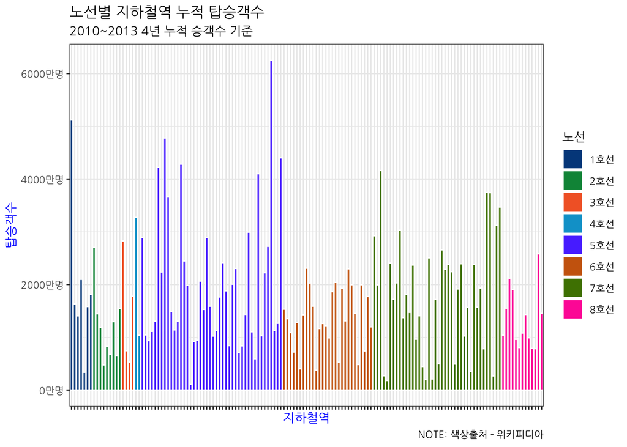

```r
col <- c("#00498B", "#009246", "#F36630", "#00A2D1", "#5940FF", "#CC660D", "#4D8000", "#FF33A6")

label_ko_num = function(num) {
  ko_num = function(x) {
    new_num = x %/% 10000
    return(paste(new_num, '만명', sep = ''))}
  return(sapply(num, ko_num))} # ~만명 단위으로 변경

ggplot(df2, aes(x=stat_name, y=total, fill=LINE_NUM)) +
  geom_bar(stat="identity", colour = "white") +
  scale_fill_manual(name="노선", values=col) +
  scale_y_continuous(labels = label_ko_num) +
  theme_bw(base_size = 10, base_family = "NanumGothic") +
  labs(x="지하철역", y="탑승객수",
        title="노선별 지하철역 누적 탑승객수",
        subtitle="2010~2013 4년 누적 승객수 기준",
        caption="NOTE: 색상출처 - 위키피디아") +
  theme(axis.title=element_text(colour="blue", size = 10)) +
  theme(axis.text.x=element_blank()) + # 지하철역명 안 나타나게
  theme(axis.text.y=element_text(size = 8)) +
  theme(legend.position="right") # 범례위치 오른쪽
```

# 3. 탑승객수 기준 상위/하위 10개역 추출 및 정보 시각화

### 4년간 탑승객 수 상위 10개역 추출

역별 누적탑승객수를 산출한 df2 의 total 변수를 `dplyr::arrange(desc())` 함수에 적용하여 상위 10개를 추출함

```r
df3 <- df2 %>%
  arrange(desc(total)) %>%
  head(10)
df3
```

```
## # A tibble: 10 x 3
## # Groups:   LINE_NUM [3]
##    LINE_NUM stat_name         total
##    <fct>    <fct>             <int>
##  1 5호선    천호           62506080
##  2 1호선    가산디지털단지 51204299
##  3 5호선    광화문         47791232
##  4 5호선    화곡           44025075
##  5 5호선    까치산         42827345
##  6 5호선    공덕           42218105
##  7 7호선    광명사거리     41624495
##  8 5호선    오목교         41014661
##  9 7호선    철산           37475643
## 10 7호선    청담           37425361
```

### 4년간 탑승객 수 상위 10개역 막대그래프 그리기

x 축을 y값이 큰 순으로 `reorder()` 하여 직관성을 높임. 앞의 그래프와 호선별 막대컬러를 동일하게 적용하고, 뒤이어서 나올 하위 10개역과의 비교를 위해 y축의 범위를 지정함. 탑승객수 순으로 재정렬.

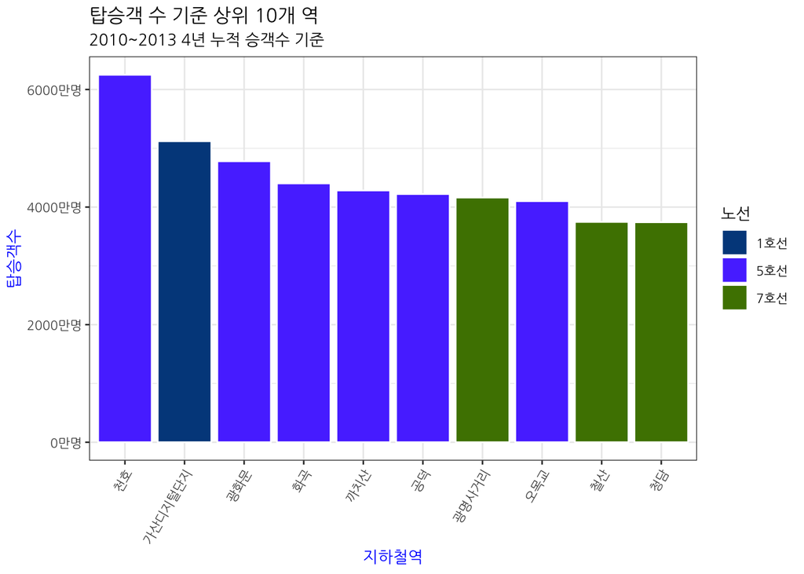

```r
ggplot(df3, aes(x = reorder(stat_name, -total), y = total, fill = LINE_NUM)) +
  geom_bar(stat="identity", colour = "white") +
  scale_fill_manual(name="노선", values=c("#00498B", "#5940FF", "#4D8000")) +
  scale_y_continuous(labels = label_ko_num, limits = c(0, max(df2$total))) +
  labs(x="지하철역", y="탑승객수",
      title="탑승객 수 기준 상위 10개 역",
      subtitle="2010~2013 4년 누적 승객수 기준") +
  theme_bw(base_size = 10, base_family = "NanumGothic") +
  theme(axis.title=element_text(colour="blue", size = 10)) +
  theme(axis.text.x = element_text(angle = 60, hjust = 1)) +
  theme(axis.text.y = element_text(size = 8)) +
  theme(legend.position="right")
```

### 4년간 탑승객 수 하위 10개역 추출

역별 누적탑승객수를 산출한 df2 의 total 변수를 `dplyr::arrange(())` 함수에 적용하여 하위 10개를 추출함

```r
df4 <- df2 %>%
  arrange((total)) %>%
  head(10)
df4
```

```
## # A tibble: 10 x 3
## # Groups:   LINE_NUM [4]
##    LINE_NUM stat_name        total
##    <fct>    <fct>            <int>
##  1 5호선    마곡           1074471
##  2 7호선    까치울         1822955
##  3 7호선    부천종합운동장 1998824
##  4 7호선    삼산체육관     2102884
##  5 7호선    춘의           2682701
##  6 7호선    굴포천         2711284
##  7 1호선    신길           3373506
##  8 7호선    장암           3535165
##  9 6호선    버티고개       3778426
## 10 6호선    독바위         4035812
```

### 4년간 탑승객 수 하위 10개역 막대그래프 그리기

y축의 범위를 c(0, max(df2$total) 로 동일한 범위로 시각화함으로써 상위 10개역과 하위 10개역 탑승객수의 비교를 용이하게 함. 탑승객수 적은 순으로 재정렬.

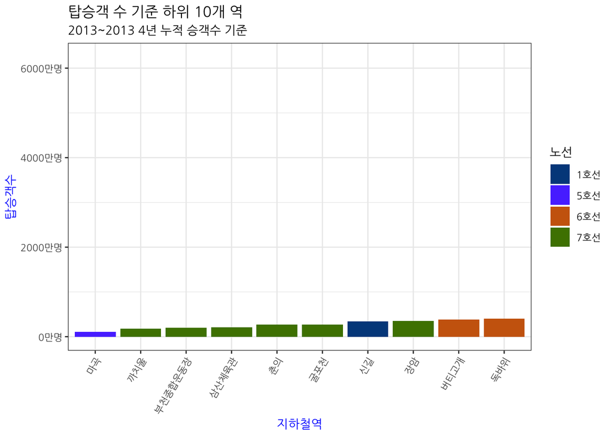

```r
ggplot(df4, aes(x = reorder(stat_name, total), y = total, fill = LINE_NUM)) +
  geom_col() +
  scale_fill_manual(name="노선", values=c("#00498B", "#5940FF", "#CC660D", "#4D8000")) +
  scale_y_continuous(labels = label_ko_num, limits = c(0, max(df2$total))) +
  labs(x="지하철역", y="탑승객수",
      title="탑승객 수 기준 하위 10개 역",
      subtitle="2013~2013 4년 누적 승객수 기준") +
  theme_bw(base_size = 10, base_family = "NanumGothic") +
  theme(axis.title=element_text(colour="blue", size = 10)) +
  theme(axis.text.x = element_text(angle = 60, hjust = 1)) +
  theme(axis.text.y = element_text(size = 8)) +
  theme(legend.position="right")
```

### 2013년 상위 10개역 월별 탑승객 추이

상위 10개역의 2013년 월별 탑승객수 추출 : month 칼럼을 갖고 있는 subway3 테이블에서 matching operatora `%in%` 와 equal operator `==` 을 이용해서 상위 10개역의 2013년도 데이터를 필터링하고 월별 탑승객의 합계를 계산함.

```r
top10_stat_num <- df3$stat_name # 상위 10개역명 변수저장
df6 <- subway3 %>%
  select(stat_name, year, month, on_tot) %>%
  filter(stat_name %in% top10_stat_num & year == "2013") %>%
  group_by(stat_name, month) %>%
  summarize(m.total = sum(on_tot))

df6$stat_name <- factor(df6$stat_name)
df6$month <- paste0(df6$month, "월") # month 표현을 '~월'로 변환
cast(df6, stat_name ~ month) #long form 을 wide formd 으로 재구조화
```

```
##         stat_name    01월    02월    03월    04월    05월    06월    07월
## 1  가산디지털단지 1271206 1110472 1232817 1251894 1247027 1131967 1245037
## 2            공덕  945549  832019  956293  982599  984666  898439  967589
## 3      광명사거리  902068  812969  936005  928141  948472  871510  887433
## 4          광화문 1056897  911615 1056304 1015697 1096603  959563 1031205
## 5          까치산  906514  814848  940785  940009  958358  882650  906772
## 6          오목교  876151  778911  881191  864917  910356  818386  847959
## 7            천호 1346816 1212976 1390001 1353688 1405015 1293521 1316566
## 8            철산  801309  724123  828196  820692  845323  767817  787575
## 9            청담  796247  691049  790426  791338  802766  730486  773061
## 10           화곡  915968  819073  951714  951462  976006  886432  911278
##       08월    09월    10월    11월    12월
## 1  1111389 1064686 1240411 1275906 1280789
## 2   879826  844840  999818  989336 1008260
## 3   842624  827812  921260  893705  911521
## 4  1017299  926417 1115845 1128216 1160915
## 5   863735  831436  940945  921146  947318
## 6   815223  754348  852067  845036  896714
## 7  1267909 1196087 1361741 1340379 1426534
## 8   741645  717074  818380  797427  821159
## 9   710590  661454  775270  768169  772212
## 10  868081  839588  962613  933079 1035609
```

### 2013년 상위 10개역 월별 탑승객수를 Line Chart 를 이용하여 시각화

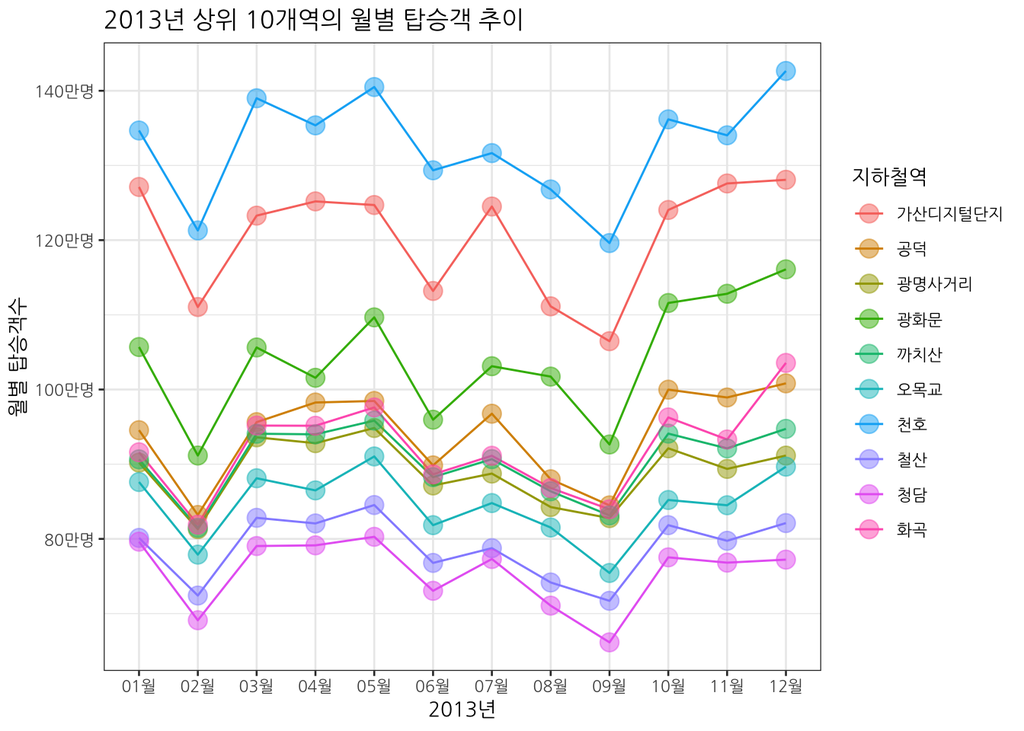

```r
ggplot(df6, aes(x=month, y=m.total, colour=stat_name, group=stat_name)) +
  geom_line() +
  theme_bw(base_size = 10, base_family = "NanumGothic") +
  geom_point(size=4, shape=19, alpha=0.5) +
  scale_x_discrete("2013년") +
  scale_y_continuous(labels = label_ko_num) +
  ylab("월별 탑승객수") +
  scale_colour_discrete(name=c("지하철역")) +
  ggtitle("2013년 상위 10개역의 월별 탑승객 추이")
```

# 4. 노선별 역당 평균 탑승객수 계산 및 비교

### 각 노선에 포함되는 역들의 평균 탑승객수 계산

노선별로 해당 역들의 탑승객수의 합을 구한 후, 노선별로 평균 탑승객수를 구함

```r
df7 <- df2 %>%
  group_by(LINE_NUM, stat_name) %>%
  summarize(sum.tot = sum(total))

df8 <- df7 %>%
  group_by(LINE_NUM) %>%
  summarize(mean.tot = mean(sum.tot)) %>%
  mutate(pct = round(mean.tot/sum(mean.tot), 4)*100)
```

### Pie Chart 를 이용하여 노선별 탑승객수를 시각화

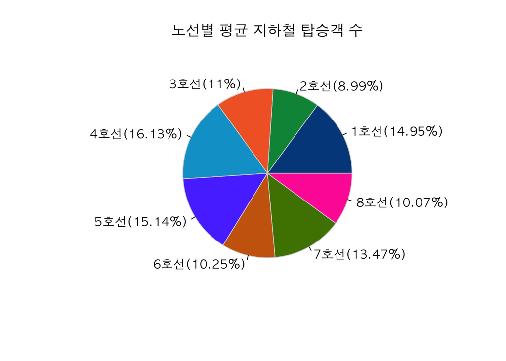

```r
col2 <- c("#00498B", "#009246", "#F36630", "#00A2D1", "#5940FF", "#CC660D", "#4D8000", "#FF33A6", "#BB1833", "#6E98BB")

label <- paste(df8$LINE_NUM, "(", df8$pct, "%", ")", sep = "")
#label <- paste0(df8$LINE_NUM, "(", df8$pct, "%", ")")

label <- paste(df8$LINE_NUM, "(", df8$pct, "%", ")", sep = "")
pie(df8$mean.tot, labels=label, col=col2, border="lightgray", main="노선별 평균 지하철 탑승객 수")
```

# 5. 노선별 누적 승객수의 상대비교

### 각 노선에 대하여 월별 총 탑승객수 계산

year 와 month 칼럼의 데이터를 결합하여 yearmonth 칼럼을 생성하고, 영역차트(area chart)를 만들기 위해 날짜형으로 변환함. 노선별 2010~2013년 월별 탑승객수 합계를 구해서 상위 3개 확인.

```r
subway3$yearmonth <- as.Date(paste(subway3$year, subway3$month, "01", sep = "-"))
df9 <-  subway3 %>%
  select(LINE_NUM, yearmonth, on_tot) %>%
  group_by(LINE_NUM, yearmonth) %>%
  summarize(ym.tot = sum(on_tot))
head(df9, 3)
```

```
## # A tibble: 3 x 3
## # Groups:   LINE_NUM [1]
##   LINE_NUM yearmonth   ym.tot
##   <chr>    <date>       <int>
## 1 1        2010-01-01 2663700
## 2 1        2010-02-01 2341933
## 3 1        2010-03-01 2877556
```

### Area Chart 로 시각화 하기

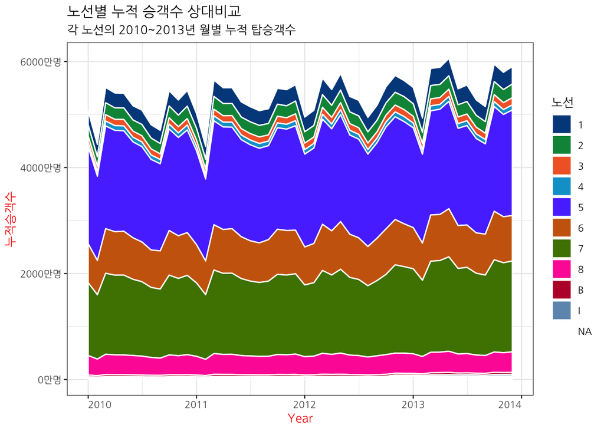

```r
col2 <- c("#00498B", "#009246", "#F36630", "#00A2D1", "#5940FF", "#CC660D", "#4D8000", "#FF33A6", "#BB1833", "#6E98BB")

ggplot(df9, aes(x=yearmonth, y=ym.tot, fill=LINE_NUM)) +
  geom_area(colour="white") +
  scale_fill_manual(name="노선", values = col2) +
  scale_y_continuous(labels = label_ko_num) +
  theme_bw(base_size = 10, base_family = "NanumGothic") +
  labs(x="Year", y="누적승객수",
        title="노선별 누적 승객수 상대비교",
        subtitle="각 노선의 2010~2013년 월별 누적 탑승객수") +
  theme(axis.title=element_text(colour="red", size = 10)) +
  theme(axis.text.x=element_text(hjust=c(0, 0.5, 0.5, 0.5, 1))) +
  theme(axis.text.y=element_text(size = 8)) +
  theme(legend.position="right")
```

### 후처리 : NA 발생 원인 확인

위 그래프의 범례에서 NA 가 나타난 원인을 추적해보니, subway와 subname join 후 (subway3) LINE_NUM 칼럼 중 총 2922 개의 NA 값이 발생한 것이 확인 됨.

```r
table(is.na(subway3$LINE_NUM))
```

```
##
##  FALSE   TRUE
## 217188   2922
```

LINE_NUM 가 매핑되지 않은 역 이름을 확인함 : “동대문역사문화공원5”, “이수”

```r
no_LINE_NUM <- subway3 %>% filter(is.na(LINE_NUM))
unique(no_LINE_NUM$stat_name)
```

```
## [1] "동대문역사문화공원5" "이수"
```

> 원인 확인
1. 동대문역사문화공원5 : 소스파일1(subway.csv)에 “동대문역사문화공원(5)”가 아니라 “동대문역사문화공원5” 로 되어 있어 “(” 로 detect 되지 않았음 (역이름 입력오류)
2. 이수 : 소스파일1(subway.csv)에는 “이수”, 소스파일2(subway_latlong.csv) 에는 “총신대입구(이수)”로 통일되지 않게 입력되어 있었기 때문에 매칭되지 않음 (환승역명이 상이할 경우의 역이름 통일오류)

> Implication
- 환승역에 대한 노선번호 입력 가이드라인을 사전에 확인할 필요가 있었음. (환승역이름 입력시에 노선번호 중 하나를 (숫자)로 표시했을 것으로 추정됨)
- 역명을 수정한다면, 아래와 같은 데이터 수정이 필요함.

```r
# 실행하지 않음.
# subway2 %>%
#   mutate(stat_name = ifelse(subway2$stat_name == "동대문역사문화공원5", "동대문역사문화공원", subway2$stat_name))
#
# subname$STATION_NM[28] <- "이수"
```